# Comparison of Southern BC historic and projected SSTs

## Introduction

Sea surface temperature (SST) is a key environmental variable for understanding marine survival and productivity of Pacific salmon. In particular, the early marine period is a critical time for salmonids, and the temperature of the ocean during this period can have a large impact on growth and survival. However, modelling historical and projected sea surface temperatures is challenging within the coastal areas of southern BC where complex oceanographic characteristics lead to unique conditions compared to the offshore areas of the North Pacific.

This notebook compares historical and projected SSTs in Southern BC across a suite of models that interpolate or hindcast past conditions and project future conditions for the mid-century period (2040-2070). Comparisons are examined both annually and for the months of April through to July, the main period of ocean entry and residence for salmon in southern BC. The comparisons focus on the Georgia Strait and West Vancouver Island marine adaptive zones (MAZs) for salmon, as well as the area offshore from the continental shelf but within the Canadian EEZ.

## Data Sources

All models were filtered to include only years after 1980.

The map below shows OISST points and Marine Adaptive Zone polygons that contain them.

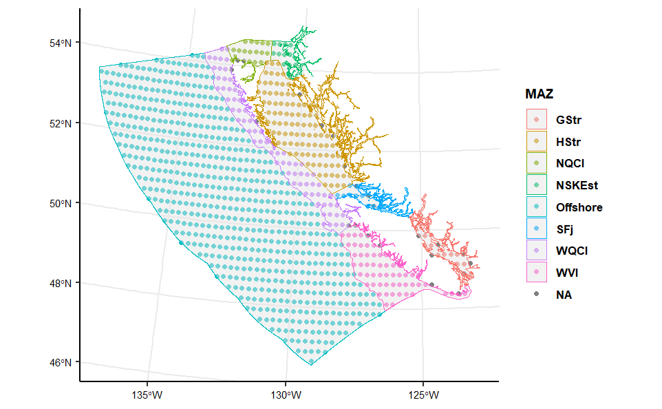

### SST Summaries

Anuual SST values corresponding to marine entry times are calculated over the months of April to July, which were the times used by Connors et al. (2020) and Mueter et al (2002). SST values are averaged for all spatial points within each marine adaptive zones for regional oceanographic model and OISST outputs. For the ERRST values, the location of river entry was designated as the marine adaptive zone location, although SST values are based on data within a 400km radius of ocean entry points.

For historical time series, we compare annual SST values as well as SST anomalies. SST anomalies are calculated as the difference between mean SST across the time series for that model and annual values.

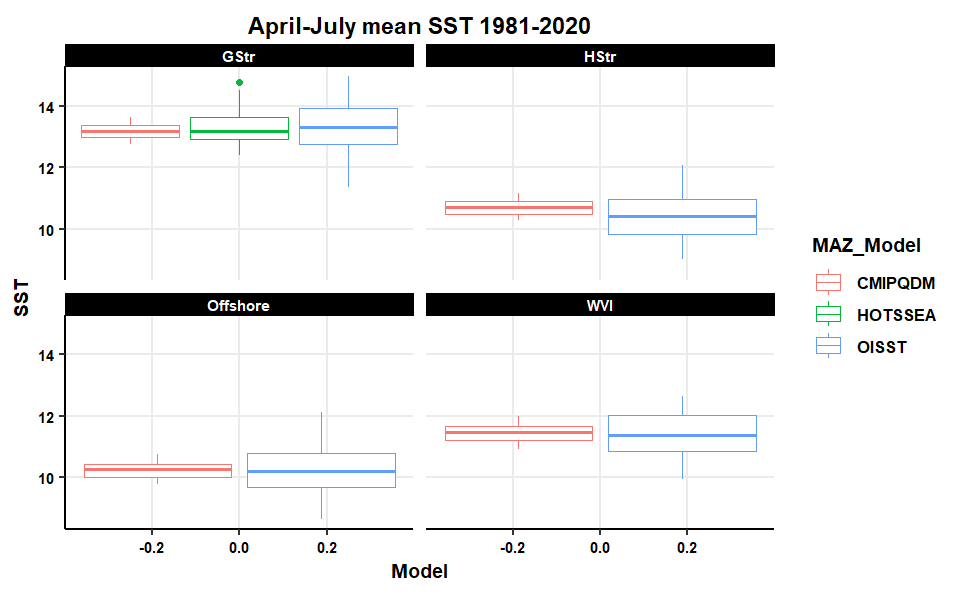

### Comparison with projected SSTs

The projected SSTs from the BCCM and Salish Sea Cast models are compared to the historical annual SSTs across models between 1980 and 2010. Regional oceanographic models (ROMs) are averaged for decadal time spans, and therefore are represented as a single value.

The BCCM SST projections are averaged across 2041-2070, while the climatology is from 1981-2010. The SalishSeaCast projection is for 2046-2065, while the historical reference period from 1986-2005.

H denotes the historical period, while 45 and 85 denote the RCP scenarios under CMIP5 and CMIP6.

Models: **OISST** - Optimum interpolated SST  
**SSC** - Salish Sea Cast, for Georgia Strait MAZ only **BCCM** - Included for all regions, but a mask is recommended for GStr **CMIP6QDM** - Averaged from 1980-2010, and 2046-2065 for the projected period

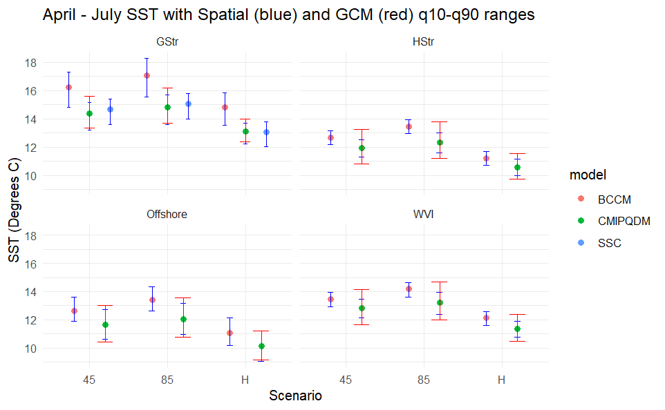

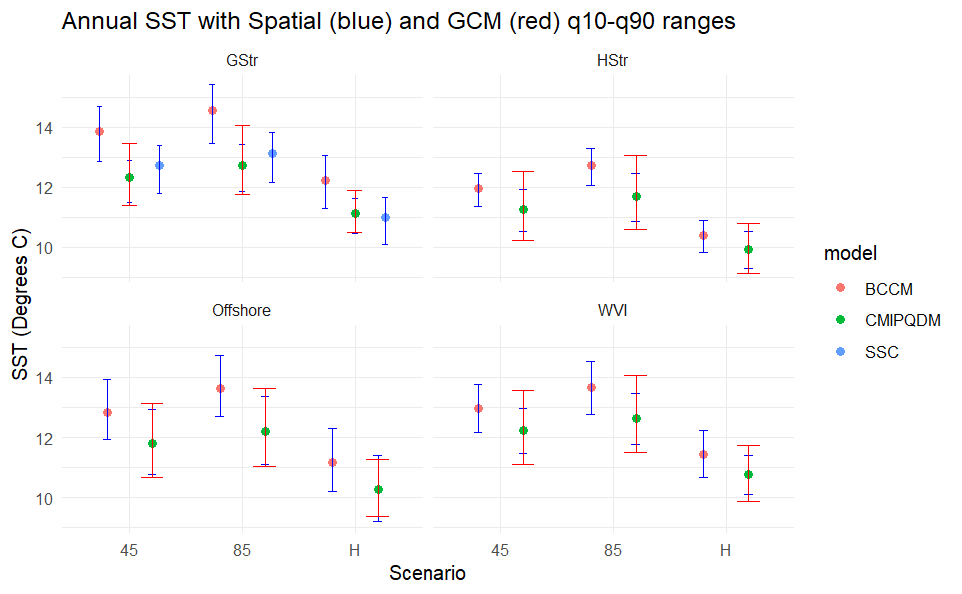